# Financial Analysis Project By KARAN SHARMA: Portfolio Diversification, Risk Management, and Strategy Development

### Table of Contents:

- 📊 Data Collection & Preprocessing
- 📰 Sentiment Analysis using News API
- 🔍 Exploratory Data Analysis (EDA)
- 💰 Portfolio Diversification & Construction (Mean–Variance Optimization)
- 📉 Portfolio Performance & Risk-Return Evaluation
- 🌪️ Risk Metrics: Value at Risk (VaR) & Conditional VaR (CVaR)
- ⚖️ Scenario Simulations (Monte Carlo) / Stress Testing
- 🧠 Mean-Variance Portfolio Strategy Development & Backtest
- 📚 Broader Implications of the Mean-Variance Optimized Portfolio Strategy

# 📝 Introduction

In this project, I will build a comprehensive financial analysis tool that focuses on portfolio diversification, risk management, and strategy development using Python. This notebook integrates multiple data sources such as historical stock prices and sentiment analysis using a Google News API. Additionally, I will use Monte Carlo simulations to optimize and manage a portfolio.

# 📊 Data Collection & Preprocessing

In this step, I will:

- Collect historical stock prices data for five different stocks of different sectors using Yahoo Finance.
  - AAPL **Apple Inc.** : Information Technology Sector
  - XOM **Exxon Mobil** : Energy Sector
  - JPM **JPMorgan Chase** : Financials Sector
  - AMZN **Amazon** : Consumer Discretionary Sector
  - JNJ **Johnson & Johnson** : Health Care Sector
- Calculate **daily returns** to measure the performance of each stock over time. The percentage change in the stock price from one day to the next.
- Collect Sentimental data for each of the stocks using **Google News Api**
- Calculate the sentimental score using **TextBlob** which can help us calculate polarity scores for each headline.
- Collect historical data for Economic indicaters, such as:
  - **10-year Treasury yield**
  - **Federal Funds Rate**

### Setup Imports

```python
import yfinance as yf
import pandas as pd
import pandas_datareader.data as web
import datetime as dt
import requests
from textblob import TextBlob
from bs4 import BeautifulSoup
import numpy as np
import warnings
import pandas as pd
import matplotlib.pyplot as plt
import seaborn as sns
import cvxpy as cp
warnings.filterwarnings('ignore')
```

### Finding Daily returns

```python
# list of tickers
tickers = ["AAPL", "XOM", "JPM", "AMZN", "JNJ"]
stock_name = ["Apple", "ExxonMobil", "JPMorgan chase", "Amazon", "Johnson & Johnson"]

# start and end dates
start_date = "2024-01-10"
end_date = "2025-01-10"

# Downloading data and selecting only the 'Close' columns
close_data = yf.download(tickers, start=start_date, end=end_date)['Close']

# Calculate daily returns using pct_change()
daily_returns = close_data.pct_change().dropna()

daily_returns.reset_index(inplace=True)

# Rename each ticker followed by "_Return"
daily_returns.columns = ["Date"] + [f"{ticker}_Return" for ticker in tickers]
daily_returns

print(daily_returns.head())
```

```
[*********************100%***********************]  5 of 5 completed
```

```
        Date  AAPL_Return  XOM_Return  JPM_Return  AMZN_Return  JNJ_Return
0 2024-01-11    -0.003223    0.009432   -0.004448    -0.004210   -0.000203
1 2024-01-12     0.001778   -0.003609    0.007695    -0.007340    0.012973
2 2024-01-16    -0.012317   -0.009442   -0.011515    -0.006270   -0.022611
3 2024-01-17    -0.005174   -0.009467   -0.000561    -0.005358   -0.007268
4 2024-01-18     0.032571    0.011799    0.004862     0.001975   -0.001856
```

# 📰 Sentiment Analysis using Google News API

```python
# Function to get news headlines and sentiment score for a specific stock and date
def get_sentiment_score(stock, Date):
    date = Date.strftime('%d %b %Y')

    # Set headers to mimic a real browser
    headers = {
        "User-Agent": "Mozilla/5.0 (Windows NT 10.0; Win64; x64) AppleWebKit/537.36 (KHTML, like Gecko) Chrome/91.0.4472.124 Safari/537.36"
    }

    # Google News RSS Feed URL
    url = f"https://news.google.com/rss/search?q={stock}+{date}&hl=en-IN&gl=IN&ceid=IN:en"

    # Fetch the RSS feed
    response = requests.get(url, headers=headers)
    if response.status_code != 200:
        print("Error fetching news feed.")
        return

    # Parse the feed using BeautifulSoup
    soup = BeautifulSoup(response.content, "xml")
    items = soup.find_all("item")

    print(f"Latest news for {stock} as of {date}:\n")

    sentiment_scores = []
    for item in items:
        title = item.title.text
        published = item.pubDate.text
        if stock in title and date in published:
            polarity, subjectivity = TextBlob(title).sentiment
            score = polarity*(1 - subjectivity)
            sentiment_scores.append(score)
            if score>0:
                res = "Positve"
            elif score == 0:
                res = "Neutral"
            else:
                res = "Negative"
            print(f'{res}:- {title}')
    if sum(sentiment_scores) == 0:
        return 0
    return sum(sentiment_scores) / len(sentiment_scores)

# Add sentiment scores for each ticker and date
for ticker, stock in zip(tickers, stock_name):
    daily_returns[f"{ticker}_Sentiment"] = daily_returns['Date'].apply(lambda x: get_sentiment_score(stock, x))

# Display the updated DataFrame with sentiment scores
print(daily_returns.head())
```

[output not shown]

[output cut: 9367 more lines]

```
Neutral:- BREAKING: Lions' Ben Johnson Scheduled to Interview With Jaguars - Sports Illustrated
Neutral:- James Johnson Obituary (2025) - Washington, PA - Observer-Reporter - Legacy.com
        Date  AAPL_Return  XOM_Return  JPM_Return  AMZN_Return  JNJ_Return  \
0 2024-01-11    -0.003223    0.009432   -0.004448    -0.004210   -0.000203
1 2024-01-12     0.001778   -0.003609    0.007695    -0.007340    0.012973
2 2024-01-16    -0.012317   -0.009442   -0.011515    -0.006270   -0.022611
3 2024-01-17    -0.005174   -0.009467   -0.000561    -0.005358   -0.007268
4 2024-01-18     0.032571    0.011799    0.004862     0.001975   -0.001856

   AAPL_Sentiment  XOM_Sentiment  JPM_Sentiment  AMZN_Sentiment  JNJ_Sentiment
0        0.124997       0.032083       0.000000        0.109274       0.007336
1        0.092264       0.000000       0.074019        0.093382       0.002570
2        0.053297       0.000000       0.010618        0.094505       0.046103
3        0.088961       0.018595       0.044108        0.050396       0.027361
4        0.056082       0.055556      -0.010000        0.108199      -0.077867
```

### 10-year Treasury yield data

```python
# Download 10-year Treasury yield data
tnx_data = yf.download("^TNX", start=start_date, end=end_date)

tnx_close = tnx_data[['Close']].reset_index()
tnx_close.columns = ["Date", "TNX_10Y"]
print(tnx_close.head())

combined_data = pd.merge(daily_returns, tnx_close, on="Date", how="left")
```

```
[*********************100%***********************]  1 of 1 completed
```

```
        Date  TNX_10Y
0 2024-01-10    4.030
1 2024-01-11    3.977
2 2024-01-12    3.950
3 2024-01-16    4.066
4 2024-01-17    4.106
```

### Federal Funds Rate data

```python
# "DFF" is the FRED code for the Effective Federal Funds Rate
fed_funds = web.DataReader("DFF", "fred", start= start_date, end= end_date)
fed_funds.reset_index(inplace=True)
fed_funds.columns = ["Date", "Fed_Funds_Rate"]
print(fed_funds.head())

combined_data = pd.merge(combined_data, fed_funds, on="Date", how="left")
```

```
        Date  Fed_Funds_Rate
0 2024-01-10            5.33
1 2024-01-11            5.33
2 2024-01-12            5.33
3 2024-01-13            5.33
4 2024-01-14            5.33
```

```python
#combined_data.to_csv("daily_returns.csv", index=False)
#combined_data = pd.read_csv("daily_returns.csv")
combined_data.head()
```

|  | Date | AAPL_Return | XOM_Return | JPM_Return | AMZN_Return | JNJ_Return | AAPL_Sentiment | XOM_Sentiment | JPM_Sentiment | AMZN_Sentiment | JNJ_Sentiment | TNX_10Y | Fed_Funds_Rate |
| --- | --- | --- | --- | --- | --- | --- | --- | --- | --- | --- | --- | --- | --- |
| 0 | 2024-01-11 | -0.003223 | 0.009432 | -0.004448 | -0.004210 | -0.000203 | 0.124997 | 0.032083 | 0.000000 | 0.109274 | 0.007336 | 3.977 | 5.33 |
| 1 | 2024-01-12 | 0.001778 | -0.003609 | 0.007695 | -0.007340 | 0.012973 | 0.092264 | 0.000000 | 0.074019 | 0.093382 | 0.002570 | 3.950 | 5.33 |
| 2 | 2024-01-16 | -0.012317 | -0.009442 | -0.011515 | -0.006270 | -0.022611 | 0.053297 | 0.000000 | 0.010618 | 0.094505 | 0.046103 | 4.066 | 5.33 |
| 3 | 2024-01-17 | -0.005174 | -0.009467 | -0.000561 | -0.005358 | -0.007268 | 0.088961 | 0.018595 | 0.044108 | 0.050396 | 0.027361 | 4.106 | 5.33 |
| 4 | 2024-01-18 | 0.032571 | 0.011799 | 0.004862 | 0.001975 | -0.001856 | 0.056082 | 0.055556 | -0.010000 | 0.108199 | -0.077867 | 4.144 | 5.33 |

```python
combined_data.columns
```

```
Index(['Date', 'AAPL_Return', 'XOM_Return', 'JPM_Return', 'AMZN_Return',
       'JNJ_Return', 'AAPL_Sentiment', 'XOM_Sentiment', 'JPM_Sentiment',
       'AMZN_Sentiment', 'JNJ_Sentiment', 'TNX_10Y', 'Fed_Funds_Rate'],
      dtype='object')
```

# 🔍 Exploratory Data Analysis (EDA)

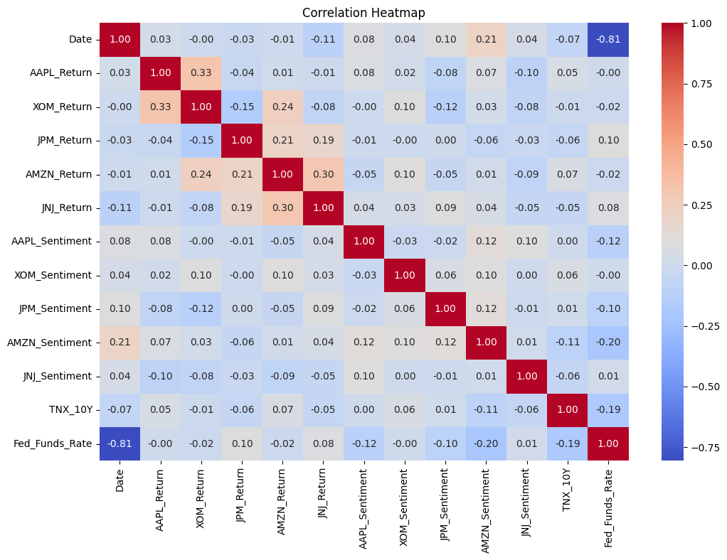

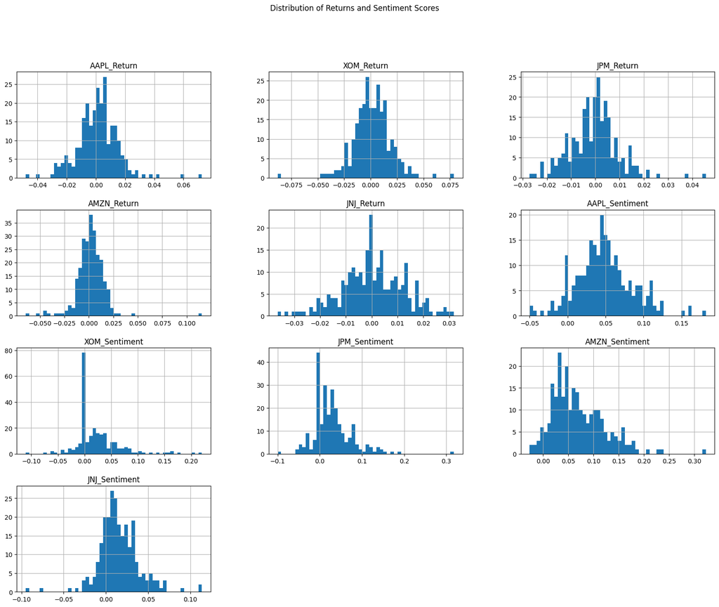

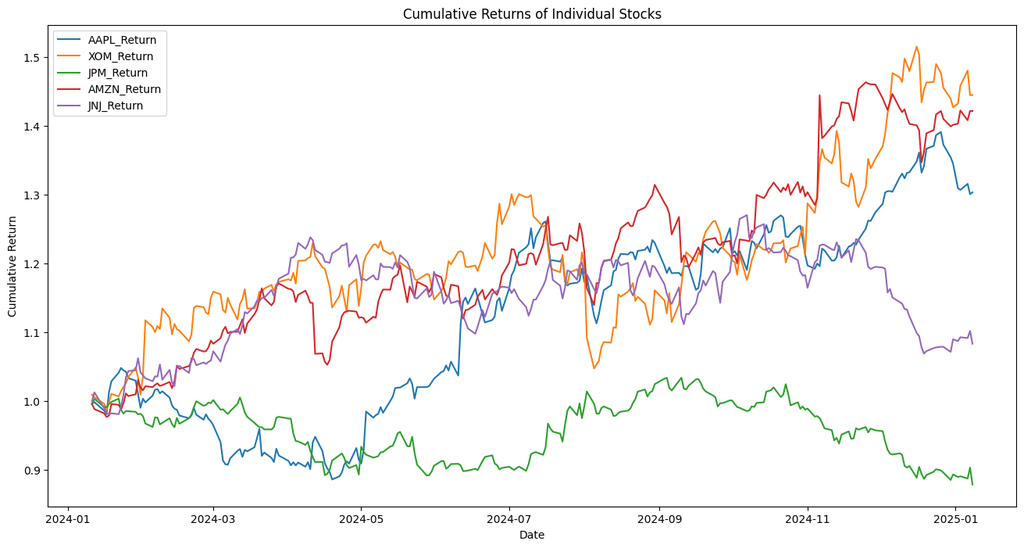

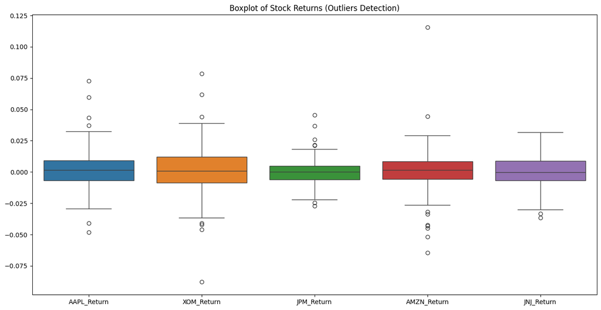

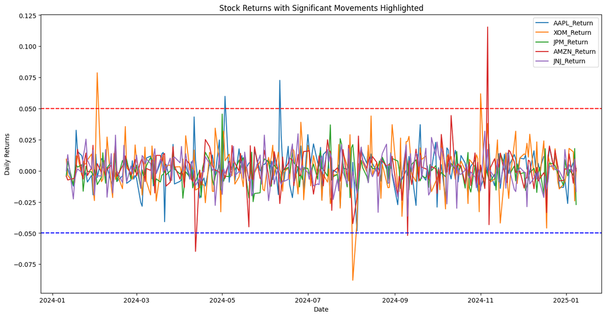

```
Correlation between AAPL_Return and TNX_10Y: 0.05
Correlation between AAPL_Return and Fed_Funds_Rate: -0.00
Correlation between XOM_Return and TNX_10Y: -0.01
Correlation between XOM_Return and Fed_Funds_Rate: -0.02
Correlation between JPM_Return and TNX_10Y: -0.06
Correlation between JPM_Return and Fed_Funds_Rate: 0.10
Correlation between AMZN_Return and TNX_10Y: 0.07
Correlation between AMZN_Return and Fed_Funds_Rate: -0.02
Correlation between JNJ_Return and TNX_10Y: -0.05
Correlation between JNJ_Return and Fed_Funds_Rate: 0.08
```

```python
df = combined_data

df['Date'] = pd.to_datetime(df['Date'])

#  Correlation Heatmap
plt.figure(figsize=(12, 8))
correlation_matrix = df.corr()
sns.heatmap(correlation_matrix, annot=True, cmap="coolwarm", fmt=".2f")
plt.title("Correlation Heatmap")
plt.show()

# Visualize the Distribution of Returns and Sentiment Scores
plt.figure(figsize=(16, 8))
df[['AAPL_Return', 'XOM_Return', 'JPM_Return', 'AMZN_Return',
       'JNJ_Return', 'AAPL_Sentiment', 'XOM_Sentiment', 'JPM_Sentiment',
       'AMZN_Sentiment', 'JNJ_Sentiment']].hist(bins=50, figsize=(20, 15))
plt.suptitle("Distribution of Returns and Sentiment Scores")
plt.show()

# Plot Cumulative Returns for Each Stock
cumulative_returns = (1 + df.iloc[:, 1:6]).cumprod()
cumulative_returns['Date'] = df['Date']

plt.figure(figsize=(16, 8))
for column in cumulative_returns.columns[:-1]:
    plt.plot(cumulative_returns['Date'], cumulative_returns[column], label=column)
plt.title("Cumulative Returns of Individual Stocks")
plt.xlabel("Date")
plt.ylabel("Cumulative Return")
plt.legend()
plt.show()

# Identify Outliers Using Boxplots
plt.figure(figsize=(16, 8))
sns.boxplot(data=df.iloc[:, 1:6])  # Returns columns
plt.title("Boxplot of Stock Returns (Outliers Detection)")
plt.show()

# Identify Anomalies or Market Events (Highlight Large Movements)
plt.figure(figsize=(16, 8))
for column in df.columns[1:6]:  # Stock returns columns
    plt.plot(df['Date'], df[column], label=column)
    plt.axhline(y=0.05, color='r', linestyle='--', alpha=0.5)  # Mark significant positive returns
    plt.axhline(y=-0.05, color='b', linestyle='--', alpha=0.5)  # Mark significant negative returns
plt.title("Stock Returns with Significant Movements Highlighted")
plt.xlabel("Date")
plt.ylabel("Daily Returns")
plt.legend()
plt.show()

# Correlation Between Market Indicators and Stock Returns
macro_columns = ['TNX_10Y', 'Fed_Funds_Rate']
for ticker in ['AAPL_Return', 'XOM_Return', 'JPM_Return', 'AMZN_Return', 'JNJ_Return']:
    for macro in macro_columns:
        corr = df[ticker].corr(df[macro])
        print(f"Correlation between {ticker} and {macro}: {corr:.2f}")
```

#### Key takeaways :

  ±5% used as thresholds (the dashed red and blue lines). That’s a reasonable heuristic for highlighting “big” daily moves.

  You can see that none of the stocks is immune to large jumps or drops, but certain names—like AMZN or XOM—hit those thresholds more often.
- **Correlation with Interest Rates**

  All the correlations with TNX_10Y (10‐year Treasury yield) and Fed Funds Rate are either very small (close to zero) or mildly negative/positive (on the order of ±0.1).

  This suggests that, at least in your sample period, day‐to‐day fluctuations in these stocks’ returns weren’t driven strongly by interest‐rate movements.

  One subtle point is that JPM, being a financial stock, does have the highest correlation with Fed Funds Rate (+0.10), which makes intuitive sense: big banks often move more in tandem with interest‐rate expectations. But even that correlation is still quite modest.

#### Overall, my EDA analysis indicates:

- **Performance:** XOM performed best cumulatively, with others clustered in a narrower range.
- **Volatility & Outliers:** Each stock exhibits outliers, but some (e.g., AMZN) appear more prone to occasional large spikes.
- **Interest‐Rate Sensitivity:** Very modest correlations, with JPM showing a slight relationship to the Fed Funds Rate but otherwise no strong link between these particular rates and daily stock returns.

# 💰 Portfolio Diversification & Construction (Mean–Variance Optimization)

```python
daily_returns.set_index('Date', inplace=True)
```

```python
df_returns = daily_returns[['AAPL_Return', 'XOM_Return', 'JPM_Return', 'AMZN_Return', 'JNJ_Return']]

mean_daily_returns = df_returns.mean()
cov_daily = df_returns.cov()
trading_days = 252

# Convert to NumPy arrays for CVXPY
annual_mean_array = mean_daily_returns.values * trading_days
annual_cov_matrix = cov_daily.values * trading_days

num_assets = len(annual_mean_array)
w = cp.Variable(num_assets)

constraints = [
    cp.sum(w) == 1,
    w >= 0,
    w <= 0.30
]

portfolio_variance = cp.quad_form(w, annual_cov_matrix)
portfolio_return = annual_mean_array @ w

lambda_ret = 1.0
objective = cp.Minimize(portfolio_variance - lambda_ret * portfolio_return)

problem = cp.Problem(objective, constraints)
result = problem.solve()

optimal_weights = w.value
assets = df_returns.columns
portfolio_weights = dict(zip(assets, optimal_weights))
print("\nMean-Variance Optimized Portfolio Weights:")
for asset, weight in portfolio_weights.items():
    print(f"{asset}: {weight:.4f}")
```

```
Mean-Variance Optimized Portfolio Weights:
AAPL_Return: 0.3000
XOM_Return: 0.3000
JPM_Return: -0.0000
AMZN_Return: 0.3000
JNJ_Return: 0.1000
```

# 📉 Portfolio Performance & Risk-Return Evaluation

- Daily Portfolio Returns (Backtest)

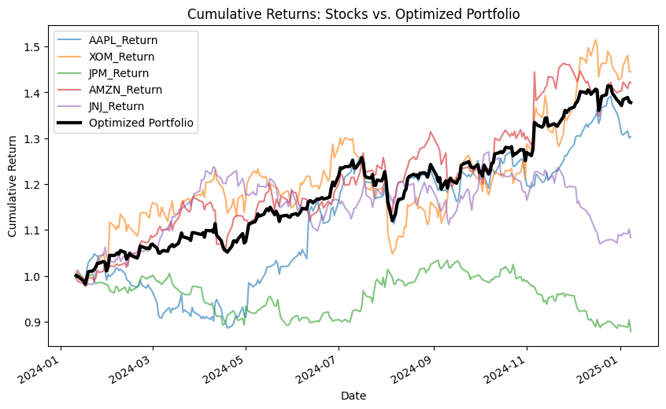

```python
# Calculate portfolio returns by multiplying each day's stock returns by the corresponding weight
df_returns['Portfolio'] = df_returns.apply(lambda row: np.dot(row.values, optimal_weights), axis=1)

# Calculate cumulative returns
df_returns['Portfolio_Cum'] = (1 + df_returns['Portfolio']).cumprod()

# Plot the portfolio vs. individual stocks
plt.figure(figsize=(10, 6))
(1 + df_returns.drop(columns=['Portfolio','Portfolio_Cum'])).cumprod().plot(ax=plt.gca(), alpha=0.6)
df_returns['Portfolio_Cum'].plot(label='Optimized Portfolio', linewidth=3, color='black')
plt.title("Cumulative Returns: Stocks vs. Optimized Portfolio")
plt.ylabel("Cumulative Return")
plt.legend()
plt.show()
```

#### Key Takeaways

1. Diversification & Reduced Volatility

   By design, many optimized portfolios won’t “beat” the single best stock (XOM here) if that one stock happened to have an outstanding run.

   However, compared to holding just JPM (a net loser), the portfolio avoided that concentrated risk.
3. Risk‐Adjusted Perspective

   Although XOM or AMZN might have higher raw returns, their volatility and drawdowns at certain points would have been greater. The portfolio’s smoother line typically leads to a higher Sharpe ratio (or similar metric) if you measure risk‐adjusted returns.
4. Practical Implication

   If your goal is consistent, less‐volatile gains rather than swinging for the fences, this portfolio is doing its job: it ends up with solid returns while maintaining lower drawdowns.
- Risk‐Return Metrics

```python
# Annualized Return (CAGR approx)
portfolio_return_daily = df_returns['Portfolio'].mean()
portfolio_vol_daily = df_returns['Portfolio'].std()

annual_return = portfolio_return_daily * trading_days
annual_vol = portfolio_vol_daily * np.sqrt(trading_days)

# Sharpe Ratio (assuming a 0% risk-free for simplicity)
sharpe_ratio = annual_return / annual_vol if annual_vol != 0 else np.nan

print("\nPortfolio Performance Metrics:")
print(f"Annualized Return: {annual_return:.4%}")
print(f"Annualized Volatility: {annual_vol:.4%}")
print(f"Sharpe Ratio: {sharpe_ratio:.2f}")

# Max Drawdown
portfolio_cum = df_returns['Portfolio_Cum']
running_max = portfolio_cum.cummax()
drawdown = (portfolio_cum - running_max) / running_max
max_drawdown = drawdown.min()
print(f"Max Drawdown: {max_drawdown:.2%}")
```

```
Portfolio Performance Metrics:
Annualized Return: 33.5453%
Annualized Volatility: 15.5551%
Sharpe Ratio: 2.16
Max Drawdown: -10.95%
```

# 🌪️ Risk Metrics: Value at Risk (VaR) & Conditional VaR (CVaR)

- Historical VaR

```python
portfolio_daily_returns = df_returns['Portfolio']

# Sort the returns from smallest (worst) to largest (best)
sorted_returns = np.sort(portfolio_daily_returns.values)

# Identify the index corresponding to the 5th percentile (for 95% VaR)
confidence_level = 0.95
index_95 = int((1 - confidence_level) * len(sorted_returns))

# The VaR is simply the negative of that return (if it's negative)
var_95 = -sorted_returns[index_95]

print(f"Historical 95% VaR: {var_95:.2%}")
```

```
Historical 95% VaR: 1.59%
```

that means on the worst 5% of days, your portfolio lost at least 1.59%.

- Conditional VaR (CVaR)

```python
# Identify all returns that are worse than the 95% VaR threshold
worst_losses = sorted_returns[:index_95+1]  # all returns below the 5th percentile
cvar_95 = -worst_losses.mean()

print(f"Historical 95% CVaR: {cvar_95:.2%}")
```

```
Historical 95% CVaR: 2.28%
```

then on average, when you do worse than the 5% worst‐case threshold, you lose 2.28%.

# ⚖️ Scenario Simulations (Monte Carlo) / Stress Testing

1. Basic Monte Carlo with Copula or Normal Assumptions

```python
import numpy as np

# Convert annual stats to daily stats for the simulation if needed
daily_mean_sim = annual_mean_array / 252
daily_cov_sim = annual_cov_matrix / 252

num_sims = 10000
simulated_returns = np.random.multivariate_normal(daily_mean_sim, daily_cov_sim, size=num_sims)

# portfolio weights
w_opt = w.value

# Each row of simulated_returns is a hypothetical 1-day scenario
# Dot with w to get the portfolio return
sim_portfolio_ret = simulated_returns @ w_opt

# Analyze distribution
var_95_sim = -np.percentile(sim_portfolio_ret, 5)
cvar_95_sim = -sim_portfolio_ret[sim_portfolio_ret <= np.percentile(sim_portfolio_ret, 5)].mean()

print(f"Simulated 1-Day 95% VaR: {var_95_sim:.2%}")
print(f"Simulated 1-Day 95% CVaR: {cvar_95_sim:.2%}")
```

```
Simulated 1-Day 95% VaR: 1.46%
Simulated 1-Day 95% CVaR: 1.86%
```

2. Extreme Market Shocks in Monte Carlo

```python
shock_factor = -0.05  # assume everything shifts down by an extra 5% daily
shocked_mean_sim = daily_mean_sim + shock_factor

simulated_shocked_returns = np.random.multivariate_normal(shocked_mean_sim, daily_cov_sim, size=num_sims)
sim_portfolio_ret_shocked = simulated_shocked_returns @ w_opt
var_95_shocked = -np.percentile(sim_portfolio_ret_shocked, 5)

print(f"95% VaR under a daily -5% shock scenario: {var_95_shocked:.2%}")
```

```
95% VaR under a daily -5% shock scenario: 6.49%
```

A 95% VaR of 6.49% under a daily −5% shock scenario means that, with the average daily returns shifted down by an extra 5%, 5% of the time your portfolio could lose more than 6.49% in a single day.

# 🧠 Mean-Variance Portfolio Strategy Development & Backtest

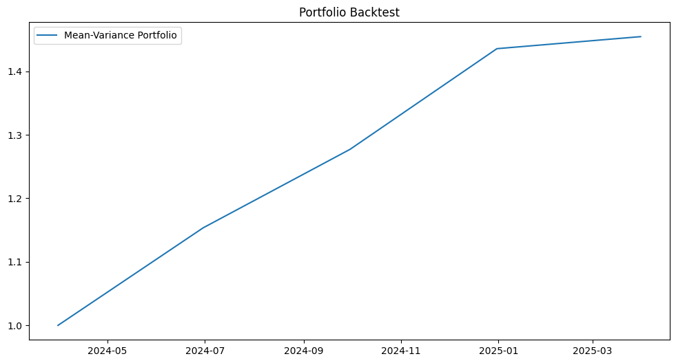

```python
from scipy.optimize import minimize

returns = daily_returns[['AAPL_Return', 'XOM_Return', 'JPM_Return', 'AMZN_Return', 'JNJ_Return']]

# Initial weights for the mean-variance optimized portfolio
initial_weights = np.array([0.30, 0.30, 0.00, 0.30, 0.10])

# Portfolio rebalancing dates (quarterly)
rebalance_dates = returns.resample('Q').mean().index

# Initialize portfolio value
portfolio_value = 1.0
portfolio_values = [portfolio_value]

# Backtest process
for i, date in enumerate(rebalance_dates[:-1]):
    # Get returns from the current date to the next rebalance date
    next_date = rebalance_dates[i + 1]
    period_returns = returns.loc[date:next_date]

    # Mean-variance optimization for the current period
    opt_result = minimize(
        lambda weights: -np.sum(period_returns.mean() * weights) / np.sqrt(np.dot(weights.T, np.dot(period_returns.cov() * 252, weights))),
        initial_weights,
        bounds=[(0, 1)] * len(tickers),
        constraints={'type': 'eq', 'fun': lambda x: np.sum(x) - 1}
    )
    weights = opt_result.x

    # Calculate portfolio performance for the period
    cumulative_return = (period_returns @ weights).sum()
    portfolio_value *= (1 + cumulative_return)
    portfolio_values.append(portfolio_value)

# Convert to Pandas Series
portfolio_values = pd.Series(portfolio_values, index=rebalance_dates)

# Plot the backtest
plt.figure(figsize=(12, 6))
plt.plot(portfolio_values, label='Mean-Variance Portfolio')
plt.title('Portfolio Backtest')
plt.legend()
plt.show()
```

# 📚 Broader Implications of the Mean-Variance Optimized Portfolio Strategy

Ethical Implications of the Strategy

The financial strategy I developed is based on mean-variance optimization, which focuses solely on maximizing returns while minimizing risk. While it seems mathematically sound, it doesn’t consider ethical factors like ESG (Environmental, Social, and Governance) criteria or broader societal impacts. Here’s why this is important:

✅ Potential Ethical Concerns:

- Ignoring ESG Risks:

  The portfolio includes companies from industries like energy (XOM), which may contribute to environmental harm (fossil fuels). Many investors are moving toward sustainable investing by prioritizing companies that reduce carbon emissions or improve social responsibility.
- Short-Termism Bias:

  Mean-variance strategies focus heavily on short-term price movements and volatility. This can incentivize trading behaviors that prioritize short-term profits at the expense of long-term value creation for society.
- Market Manipulation and Misuse:

  If large institutions use such strategies to maximize short-term gains, it can result in market manipulation, volatility spikes, and liquidity issues in certain stocks. Example: Flash crashes triggered by algorithmic trading have been linked to unethical high-frequency trading practices.

### Practical Challenges in Real-World Application

While the backtest looks promising, real-world portfolio management is far more complex due to the following practical challenges:

⚠️ Key Challenges:

1. Data Availability and Accuracy 📊
   - Historical data from platforms like Yahoo Finance is often limited, incomplete, or contains errors.
   - Professional investors rely on paid data providers (e.g., Bloomberg, Refinitiv) to ensure accurate, real-time data.
2. Transaction Costs 💰
   - The backtest ignores transaction costs such as:
   - Brokerage fees for buying/selling assets
   - Bid-ask spreads (the difference between buy and sell prices)
   - High rebalancing frequency increases costs, which can erode returns.
3. Liquidity Constraints 💧
   - In real markets, liquidity can vary significantly across assets. For example: AAPL and AMZN are highly liquid, meaning you can buy/sell large volumes without affecting prices. Small-cap stocks or bonds may have limited liquidity, causing slippage (buying/selling at worse-than-expected prices).
4. Market Frictions and Regulations 📜
   - Real-world markets are not frictionless, as assumed in mean-variance models.
   - Regulatory constraints, such as capital gains taxes or short-selling restrictions, can limit the strategy’s applicability.

### Market Efficiency and Potential Misuses

The mean-variance optimization strategy relies on historical returns and covariances to predict future performance. This assumption works well in inefficient markets, but may fail in highly efficient markets like the U.S. stock market, where prices are already influenced by publicly available information.

Future Improvements and Extensions Here’s how you can enhance the strategy to adapt to evolving market conditions:

🧠 A. Factor-Based Portfolio Optimization Instead of only optimizing based on mean-variance, incorporate multiple risk factors:

Momentum: Overweight stocks that have recently performed well. Value: Overweight stocks that are undervalued based on fundamentals. Quality: Overweight stocks with strong financials (e.g., low debt, high ROE).

🔧 B. Dynamic Rebalancing Frequency Instead of fixed quarterly rebalancing, use dynamic rebalancing based on market volatility:

High volatility → more frequent rebalancing Low volatility → less frequent rebalancing

📡 C. Use Machine Learning for Return Predictions Incorporate machine learning models to predict future returns and volatility, rather than relying solely on historical averages.